# IUSA Trash Audit, Spring 2018

Jessica McKinney, Damon Pham

February 20, 2018

In February, we conducted an audit of trash and recycling bins across campus. We were interested in knowing how well items are sorted, in order to learn what kind of changes might be helpful. Here is a table with all the data we collected:

Audit Data

| date | Bin Information location | Bin Information bin type | Bin Information paired bin | Recycling all recycling | Recycling paper | Recycling plastic | Recycling glass or metal | Trash trash | notes |
| --- | --- | --- | --- | --- | --- | --- | --- | --- | --- |
| 2/2/18 | psych bus stop | trash | FALSE | 51 | 19 | 31 | 1 | 67 | most trash are cups or wrappers |
| 2/2/18 | 10th and Forrest | trash | TRUE | 20 | 10 | 10 | 0 | 18 | 3 trash items were compostable |
| 2/2/18 | 10th and Forrest | recycling | TRUE | 2 | 0 | 2 | 0 | 1 |  |
| 2/2/18 | 10th and Arboretum | trash | TRUE | 14 | 3 | 11 | 0 | 40 | trash amount is a rough estimate |
| 2/2/18 | 10th and Arboretum | recycling | TRUE | 35 | 10 | 25 | 0 | 20 |  |
| 2/2/18 | Gresham Parking Lot | trash | FALSE | 9 | 1 | 8 | 0 | 20 |  |
| 2/2/18 | Wells Library | trash | TRUE | 35 | NA | NA | NA | 60 |  |
| 2/2/18 | Wells Library | recycling | TRUE | 52 | NA | NA | NA | 15 |  |
| 2/9/18 | woods between MAC and Simon | trash | FALSE | 2 | 0 | 2 | 0 | 10 |  |
| 2/9/18 | Goodbody 1 | trash | TRUE | 8 | 2 | 6 | 0 | 10 | trash amount is rough estimate. all trash was compost. |
| 2/9/18 | Goodbody 1 | recycling | TRUE | 8 | 2 | 6 | 0 | 6 | trash was all compostable Coke cups |
| 2/9/18 | Goodbody 2 | trash | TRUE | 21 | 6 | 15 | 0 | 25 | almost all trash is compost |
| 2/9/18 | Goodbody 2 | recycling | TRUE | 15 | 0 | 15 | 0 | 8 | trash was chip bags straws and wrappers. |
| 2/9/18 | Jordan | trash | TRUE | 4 | 2 | 2 | 0 | 1 |  |
| 2/9/18 | Jordan | recycling | TRUE | 5 | 3 | 2 | 0 | 5 |  |
| 2/9/18 | Jordan bus stop | trash | TRUE | 4 | 1 | 3 | 0 | 15 |  |
| 2/9/18 | Jordan bus stop | recycling | TRUE | 7 | 1 | 6 | 0 | 4 |  |
| 2/9/18 | behind Lindley | recycling | TRUE | 11 | 2 | 9 | 0 | 5 |  |
| 2/9/18 | behind Lindley | trash | TRUE | 13 | 4 | 9 | 0 | 20 |  |
| 2/9/18 | Swain East | recycling | TRUE | 9 | 0 | 7 | 2 | 17 |  |
| 2/9/18 | Swain East | trash | TRUE | 6 | 2 | 4 | 0 | 10 |  |
| 2/9/18 | Swain bike racks | recycling | TRUE | 2 | 1 | 1 | 0 | 3 |  |
| 2/9/18 | Swain bike racks | trash | TRUE | 3 | 2 | 1 | 0 | 10 |  |
| 2/9/18 | Kirkwood Hall | recycling | TRUE | 18 | 7 | 11 | 0 | 10 |  |
| 2/9/18 | Kirkwood Hall | trash | TRUE | 11 | 1 | 10 | 0 | 18 |  |
| 2/9/18 | Ballantine Hall | recycling | TRUE | 40 | 30 | 10 | 0 | 19 | recycling amounts are estimates. |
| 2/9/18 | Ballantine Hall | trash | TRUE | 30 | 10 | 20 | 0 | 20 | recycling amounts are estimates. |
| 2/16/18 | Jordan river/Auditorium | trash | FALSE | 15 | 1 | 12 | 2 | 25 |  |
| 2/16/18 | Jordan river/bridge | trash | FALSE | 2 | 1 | 1 | 0 | 10 |  |
| 2/16/18 | Jordan river/Ballantine | trash | FALSE | 33 | 5 | 28 | 0 | 20 |  |
| 2/16/18 | IMU bus stop | trash | FALSE | 22 | 5 | 14 | 3 | 15 |  |
| 2/16/18 | IMU patio 1 | trash | FALSE | 5 | 0 | 5 | 0 | 10 |  |
| 2/16/18 | IMU patio 2 | trash | FALSE | 1 | 0 | 1 | 0 | 3 |  |
| 2/16/18 | IMU 1 | trash | FALSE | 0 | 0 | 0 | 0 | 2 |  |
| 2/16/18 | IMU 2 | trash | FALSE | 2 | 1 | 1 | 0 | 7 |  |

We also made the following qualitative observations:

- Unseparated cups+lids+straws/sleeves were a large volume of both the trash and recycling streams.
- In regions with only trash bins, usually only one was heavily-used, while the others were almost empty.
- The lids of many of the bins were littered with gum.

## Analysis

We began by comparing item distributions for the three different bin types. Below, the left plot shows the raw item counts, and the right plot shows the item percentages.

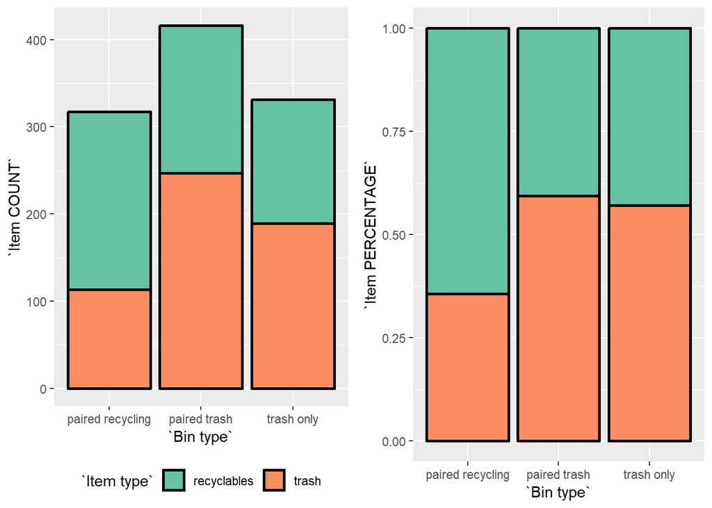

- *Overall, are the trash and recycling streams pure?*: No, they are quite contaminated. Many recyclables end up in the trash, and many trash items end up in the recycling. Less than half of all recyclable items are recycled.
- *Are paired trash bins more pure than lone trash bins?*: Not by a large margin, which is surprising. We expected paired trash bins to be much more pure, i.e. have a lower proportion of recyclables, because people should be using the adjacent recycling bin instead. However, paired trash bins had almost the same proportion of recyclables as single trash bins (~40%).

Next, we looked at the proportion of recyclables which were correctly recycled for each paired bin. The below plot only shows pairs in which each bin had at least 10 items.

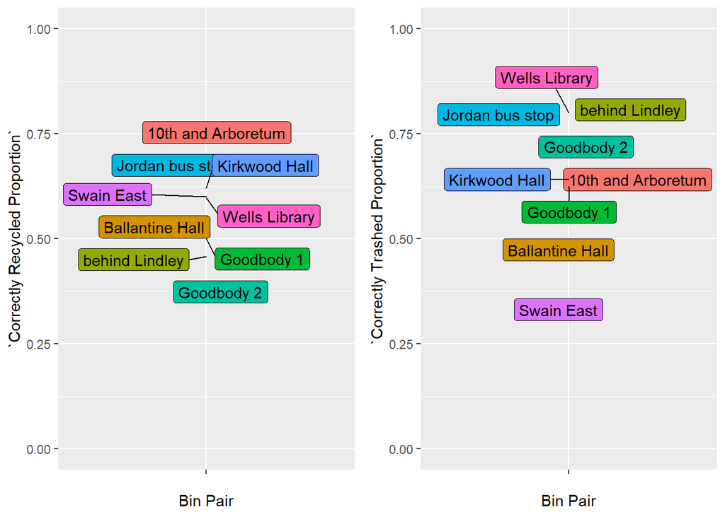

At each paired bin, recyclabes are correctly sorted about 60% of the time, and trash items are correctly sorted about 70% of the time. There does not seem to be any geographic trends, but across campus there is a lot of room for improvement.

## Conclusion and Recommendations

Recycling and trash streams are not as pure as we’d hope. The data shows that items are not being sorted properly, even at the paired bins. Because of this, we believe that the most important priority should be improving recycling rates at paired bins, rather than adding more recycling bins on campus. We propose the following two recommendations:

1. *Improved marking of recycling bins*: Currently, recycling bins are only distinguished by text on their rims. We believe this might be one reason why recycling rates are low: people who are in a hurry may simply toss their item into whichever bin is closest. By making the recycling bin more obviously-marked, people might give more thought to what bin their item elongs to. Here are some ideas on how the recycling bins can be distinguished:
   - Painting the striped exterior red-and-white.
   - Decorating the exterior with artwork from students in the School of Art and Design.
   - Decorating only the lid with artwork from students in the School of Art and Design. This would be a large aesthetic improvement, since the lids currently have lots of gum attached.
2. *Educate the public on what components of cups are recyclable*: We observed that cups/lids/straws/sleeves make up a huge proportion of the trash and recycling streams. It is important that people know what parts can be recycled, but even we don’t know this information completely! Our committee will address this recommendation on our own by researching what cup components are recyclable and creating PSA-type posters.

In addition, while we did not identify adding more recycling bins to be a priority, we believe the following recommendation is reasonable:

3. *Replacing some trash bins with recycling bins*: We noticed that the Jordan Woods and the North IMU entrance near the Hutton Honors College were two areas with many trash bins but no recycling bins at all. Furthermore, usually only one of these trash bins was heavily used, while the others were almost empty. We think it would be helpful to replace one of the trash bins with a recycling bin. Since only the label would change, this should not be a large expenditure.